# Class 9 - In class exercises

Hari Subhash

Date created: 2019-04-05

## Task Set 1: dplyr recap

Time to complete: 8 mins

1. Complete the code below to select the first 3 columns, `dep_delay` and `carrier` columns from flights data and filter all flights that were delayed by more than 2 hours.

| year | month | day | dep_delay | carrier |
| --- | --- | --- | --- | --- |
| 2013 | 1 | 1 | 853 | MQ |
| 2013 | 1 | 1 | 144 | UA |
| 2013 | 1 | 1 | 134 | UA |
| 2013 | 1 | 1 | 122 | B6 |
| 2013 | 1 | 1 | 290 | EV |
| 2013 | 1 | 1 | 260 | EV |
| 2013 | 1 | 1 | 131 | AA |
| 2013 | 1 | 1 | 129 | MQ |
| 2013 | 1 | 1 | 155 | EV |
| 2013 | 1 | 1 | 157 | MQ |

[output cut: 990 more lines]

2. Complete the following code to create a new variable that is the difference between `dep_delay` and average monthly delay for each origin airport.

| year | month | day | dep_time | sched_dep_time | dep_delay | arr_time | sched_arr_time | arr_delay | carrier | flight | tailnum | origin | dest | air_time | distance | hour | minute | time_hour | orgmo_avg | orgmo_diff |
| --- | --- | --- | --- | --- | --- | --- | --- | --- | --- | --- | --- | --- | --- | --- | --- | --- | --- | --- | --- | --- |
| 2013 | 1 | 1 | 517 | 515 | 2 | 830 | 819 | 11 | UA | 1545 | N14228 | EWR | IAH | 227 | 1400 | 5 | 15 | 2013-01-01 05:00:00 | 14.905748 | -12.9057483 |
| 2013 | 1 | 1 | 533 | 529 | 4 | 850 | 830 | 20 | UA | 1714 | N24211 | LGA | IAH | 227 | 1416 | 5 | 29 | 2013-01-01 05:00:00 | 5.641560 | -1.6415604 |
| 2013 | 1 | 1 | 542 | 540 | 2 | 923 | 850 | 33 | AA | 1141 | N619AA | JFK | MIA | 160 | 1089 | 5 | 40 | 2013-01-01 05:00:00 | 8.615826 | -6.6158261 |
| 2013 | 1 | 1 | 544 | 545 | -1 | 1004 | 1022 | -18 | B6 | 725 | N804JB | JFK | BQN | 183 | 1576 | 5 | 45 | 2013-01-01 05:00:00 | 8.615826 | -9.6158261 |
| 2013 | 1 | 1 | 554 | 600 | -6 | 812 | 837 | -25 | DL | 461 | N668DN | LGA | ATL | 116 | 762 | 6 | 0 | 2013-01-01 06:00:00 | 5.641560 | -11.6415604 |
| 2013 | 1 | 1 | 554 | 558 | -4 | 740 | 728 | 12 | UA | 1696 | N39463 | EWR | ORD | 150 | 719 | 5 | 58 | 2013-01-01 05:00:00 | 14.905748 | -18.9057483 |
| 2013 | 1 | 1 | 555 | 600 | -5 | 913 | 854 | 19 | B6 | 507 | N516JB | EWR | FLL | 158 | 1065 | 6 | 0 | 2013-01-01 06:00:00 | 14.905748 | -19.9057483 |
| 2013 | 1 | 1 | 557 | 600 | -3 | 709 | 723 | -14 | EV | 5708 | N829AS | LGA | IAD | 53 | 229 | 6 | 0 | 2013-01-01 06:00:00 | 5.641560 | -8.6415604 |
| 2013 | 1 | 1 | 557 | 600 | -3 | 838 | 846 | -8 | B6 | 79 | N593JB | JFK | MCO | 140 | 944 | 6 | 0 | 2013-01-01 06:00:00 | 8.615826 | -11.6158261 |
| 2013 | 1 | 1 | 558 | 600 | -2 | 753 | 745 | 8 | AA | 301 | N3ALAA | LGA | ORD | 138 | 733 | 6 | 0 | 2013-01-01 06:00:00 | 5.641560 | -7.6415604 |

[output cut: 990 more lines]

| year | month | day | dep_time | sched_dep_time | dep_delay | arr_time | sched_arr_time | arr_delay | carrier | flight | tailnum | origin | dest | air_time | distance | hour | minute | time_hour |
| --- | --- | --- | --- | --- | --- | --- | --- | --- | --- | --- | --- | --- | --- | --- | --- | --- | --- | --- |
| 2013 | 1 | 9 | 641 | 900 | 1301 | 1242 | 1530 | 1272 | HA | 51 | N384HA | JFK | HNL | 640 | 4983 | 9 | 0 | 2013-01-09 09:00:00 |
| 2013 | 1 | 10 | 1121 | 1635 | 1126 | 1239 | 1810 | 1109 | MQ | 3695 | N517MQ | EWR | ORD | 111 | 719 | 16 | 35 | 2013-01-10 16:00:00 |
| 2013 | 3 | 17 | 2321 | 810 | 911 | 135 | 1020 | 915 | DL | 2119 | N927DA | LGA | MSP | 167 | 1020 | 8 | 10 | 2013-03-17 08:00:00 |

## Task Set 2: Keys

Time to complete: 10 mins

Identify the keys in all the datasets included in the planes data (2 of these were discussed in the prep)

1. airlines
2. airports
3. planes
4. weather
5. flights

## Task Set 3: Joins

Time to complete: 15 mins

1. Complete the code below to see if there are any observations in the `flights` data that are not there in `planes`

| tailnum | carrier |
| --- | --- |
| N3ALAA | AA |
| N3DUAA | AA |
| N542MQ | MQ |
| N730MQ | MQ |
| N9EAMQ | MQ |
| N532UA | UA |
| N3EMAA | AA |
| N518MQ | MQ |
| N3BAAA | AA |
| N3CYAA | AA |

[output cut: 718 more lines]

2. Replace the `anti_join()` with a `semi_join()` to see all the flights that have corresponding information in `planes`.

| tailnum | carrier |
| --- | --- |
| N14228 | UA |
| N24211 | UA |
| N619AA | AA |
| N804JB | B6 |
| N668DN | DL |
| N39463 | UA |
| N516JB | B6 |
| N829AS | EV |
| N593JB | B6 |
| N793JB | B6 |

[output cut: 990 more lines]

3. Complete the code below to find the average departure delay by the year of the planes manufacture. Note that since both the flights and the planes data have a column called year they will be represented as year.x and year.y (x being the first table in the join and y the second).

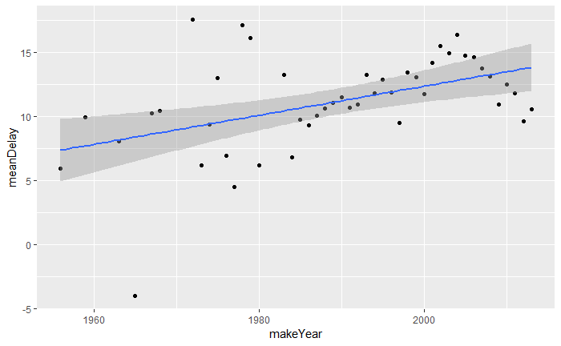

## Task Set 4

Time to complete: 20 mins

1. **Hard** As noted in the class prep, there are duplicate keys in the weather data. Remove these (read the two options in the prep) and then use a `left_join()` to join it to flights. Draw a chart of your choice (you can choose to summarise the data if you want) to show the relationship with precipitation (`precip`)

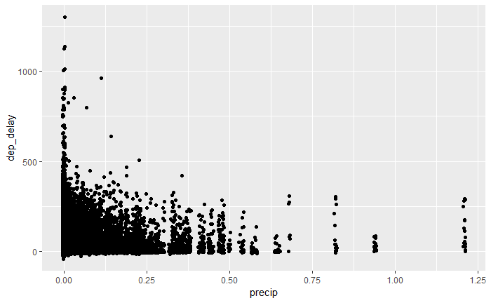

2. **Hard**: Use the `faa` code to combine the `flights` data with `airports` to study the effect of altitude on arrival delay.

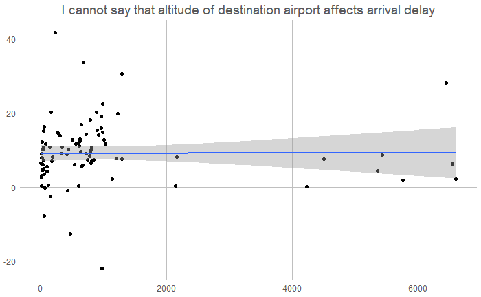

```r
flights %>%
  inner_join(airports %>% mutate(dest = faa)) %>%
  group_by(alt) %>%
  summarize(mean_arrdelay = mean(arr_delay,na.rm = T)) %>%
  ggplot(mapping = aes(x = alt, y=mean_arrdelay, na.rm = T)) +
  geom_point(na.rm = T) +
  geom_smooth(method = lm,na.rm = T) +
  labs(title = 'I cannot say that altitude of destination airport affects arrival delay',
       subtitle = 'Really just all over the place',
       x = 'Altitude of destination airport in feet',
       y = 'Mean arrival delay in minutes') +
  ggthemes::theme_excel_new()
```